# Lab 11 Part 1: Structural Time Series — and Two Ways to Get the Interval Wrong

ECON 8310: Business Forecasting — University of Nebraska at Omaha

# What we are doing

A structural model writes a series as parts you can name — a level that drifts, a seasonal shape, and noise — and puts a prior on each. The output is not a forecast line but a distribution for every future week.

Today you will build one, hit a failure the diagnostics catch, fix it — and then find that the *correct* way to forecast produces a worse-calibrated interval than the shortcut.

That last result is not a mistake in the lab. It is the model telling you something, and working out what takes the rest of the session.

**Suggested time:** ~40 minutes · **You will need:** `pandas`, `numpy`, `matplotlib`, `pymc`, `arviz`, and `data/processed/m5_weekly.csv`. Sampling takes about 20 seconds per fit.

# Setup

```python
import pandas as pd
import numpy as np
import matplotlib.pyplot as plt
import pymc as pm
import arviz as az
import warnings, logging
warnings.filterwarnings('ignore')
logging.getLogger('pymc').setLevel(logging.ERROR)

from pathlib import Path

def data_path(name):
    for base in (Path.cwd(), *Path.cwd().parents):
        p = base / "data" / "processed" / name
        if p.exists():
            return p
    raise FileNotFoundError(
        f"Could not find data/processed/{name}. "
        "Run `python scripts/prep_m5.py` from the repository root first.")

weekly = pd.read_csv(data_path("m5_weekly.csv"), parse_dates=["week_start"])
ca1 = (weekly[(weekly.store_id == "CA_1") & (weekly.cat_id == "FOODS")]
         .sort_values("week_start").reset_index(drop=True))

N_TEST = 52
train, test = ca1.iloc[:-N_TEST], ca1.iloc[-N_TEST:]
y = train.units.values.astype(float)
n = len(train)
y_mu, y_sd = y.mean(), y.std()
y_z = (y - y_mu) / y_sd          # standardize: the priors below assume unit scale

K, P = 3, 52                     # 3 Fourier pairs, annual period on weekly data
def fourier(t):
    return np.column_stack([f(2*np.pi*k*t/P) for k in range(1, K+1) for f in (np.sin, np.cos)])
t_all = np.arange(len(ca1))
X_tr, X_te = fourier(t_all[:n]), fourier(t_all[n:])

print(f"train {n} weeks, test {N_TEST} weeks | {2*K} Fourier coefficients standing in for 52")
```

```
train 225 weeks, test 52 weeks | 6 Fourier coefficients standing in for 52
```

# Step 1 — Fit it the obvious way

The model is a drifting level plus seasonality. PyMC has a distribution for a random walk, so the natural thing is to use it.

```python
with pm.Model() as centered:
    sigma_level = pm.Exponential("sigma_level", 10.0)
    level = pm.GaussianRandomWalk("level", sigma=sigma_level, shape=n)
    beta  = pm.Normal("beta", 0, 0.5, shape=2*K)
    sigma = pm.Exponential("sigma", 1.0)
    pm.Normal("obs", mu=level + pm.math.dot(X_tr, beta), sigma=sigma, observed=y_z)
    idata_c = pm.sample(1500, tune=2000, chains=4, progressbar=False,
                        random_seed=42, target_accept=0.95)

s_c = az.summary(idata_c, var_names=["sigma_level", "sigma", "beta"],
                 ci_kind="hdi", ci_prob=0.94)
print(f"R-hat        {s_c.r_hat.max():.3f}   (want < 1.01)")
print(f"ESS (bulk)   {s_c.ess_bulk.min():.0f}     (want > 400)")
print(f"divergences  {int(idata_c.sample_stats.diverging.sum())}")
```

```
R-hat        1.022   (want < 1.01)
ESS (bulk)   274     (want > 400)
divergences  0
```

**It did not converge.** No exception, a forecast is available, and the diagnostics are the only thing telling you not to use it. Note that `target_accept` is already at 0.95 — this is not fixed by asking the sampler to try harder.

# Step 2 — Reparameterize

The problem is the *shape* of the posterior, not the model. Write the walk as a cumulative sum of standard Normal draws scaled by `sigma_level`, and the sampler gets a geometry it can navigate.

```python
with pm.Model() as model:
    sigma_level = pm.Exponential("sigma_level", 10.0)
    z = pm.Normal("z", 0, 1, shape=n)                              # standard normal
    level = pm.Deterministic("level", pm.math.cumsum(z * sigma_level))
    beta  = pm.Normal("beta", 0, 0.5, shape=2*K)
    sigma = pm.Exponential("sigma", 1.0)
    pm.Normal("obs", mu=level + pm.math.dot(X_tr, beta), sigma=sigma, observed=y_z)
    idata = pm.sample(1500, tune=2000, chains=4, progressbar=False,
                      random_seed=42, target_accept=0.95)

s = az.summary(idata, var_names=["sigma_level", "sigma", "beta"], ci_kind="hdi", ci_prob=0.94)
print(f"R-hat        {s.r_hat.max():.3f}   (want < 1.01)")
print(f"ESS (bulk)   {s.ess_bulk.min():.0f}    (want > 400)")
print(f"divergences  {int(idata.sample_stats.diverging.sum())}")
```

```
R-hat        1.002   (want < 1.01)
ESS (bulk)   2376    (want > 400)
divergences  0
```

**Same model, same data, same priors.** `cumsum(z * sigma)` and `GaussianRandomWalk(sigma=sigma)` describe the identical distribution — only the coordinates the sampler explores have changed.

Look at the components it recovered:

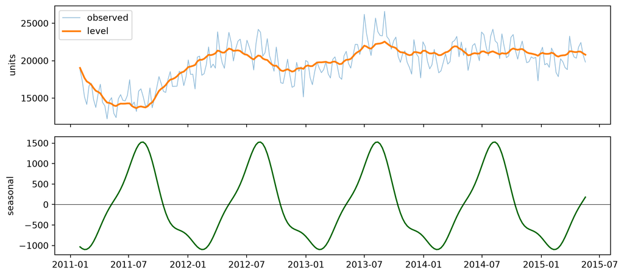

```python
lev = idata.posterior["level"].values.reshape(-1, n).mean(0) * y_sd + y_mu
sea = (idata.posterior["beta"].values.reshape(-1, 2*K) @ X_tr.T).mean(0) * y_sd

fig, ax = plt.subplots(2, 1, figsize=(10, 4.5), sharex=True)
ax[0].plot(train.week_start, train.units, lw=.8, alpha=.5, label="observed")
ax[0].plot(train.week_start, lev, lw=2, label="level")
ax[0].legend(); ax[0].set_ylabel("units")
ax[1].plot(train.week_start, sea, lw=1.5, color="darkgreen")
ax[1].set_ylabel("seasonal"); ax[1].axhline(0, color="k", lw=.5)
plt.tight_layout()
```

# Step 3 — Forecast, two ways

To forecast you need the level at each future week. There are two candidates, and one of them is theoretically right.

**Held constant:** carry the last estimated level forward unchanged. Simple, and it asserts the level stops drifting the moment your data ends — which is not what the model says.

**Propagated:** let the level keep random-walking forward, exactly as it did in-sample. This is what the fitted model actually implies.

```python
rng = np.random.default_rng(42)
post = idata.posterior
lev_last = post["level"].values[:, :, -1].ravel()
sl       = post["sigma_level"].values.ravel()
b        = post["beta"].values.reshape(-1, 2*K)
sg       = post["sigma"].values.ravel()
D = len(lev_last)
actual = test.units.values

# The POINT forecast is identical for both methods, and not approximately so:
# propagating the level adds zero-mean steps, so E[level] is unchanged. Only the
# spread differs. Compute the point forecast once, from the deterministic part.
point = (lev_last[:, None] + b @ X_te.T).mean(0) * y_sd + y_mu
rmse_point = float(np.sqrt(np.mean((actual - point) ** 2)))

def score(draws, label):
    lo, hi = np.percentile(draws, [3, 97], axis=0) * y_sd + y_mu
    return {"method": label,
            "RMSE": round(rmse_point),
            "coverage_%": round(100*float(np.mean((actual >= lo) & (actual <= hi)))),
            "mean_width": round(float(np.mean(hi - lo)))}

# (a) level held constant at its last value  -- the tempting shortcut
mu_a = lev_last[:, None] + b @ X_te.T
draws_a = mu_a + rng.normal(0, 1, size=mu_a.shape) * sg[:, None]

# (b) level keeps random-walking into the future -- what the model actually says
steps = rng.normal(0, 1, size=(D, N_TEST)) * sl[:, None]
mu_b = lev_last[:, None] + np.cumsum(steps, axis=1) + b @ X_te.T
draws_b = mu_b + rng.normal(0, 1, size=mu_b.shape) * sg[:, None]

print(pd.DataFrame([score(draws_a, "level held constant"),
                    score(draws_b, "level propagated")]).to_string(index=False))
```

```
             method  RMSE  coverage_%  mean_width
level held constant  1589          96        6340
   level propagated  1589         100       11667
```

**The theoretically correct choice calibrated worse. Work out why.**

The two methods have the **same point forecast** — not nearly the same, exactly the same, because propagating the level adds steps with mean zero. So RMSE cannot distinguish them, and everything that separates them lives in the **interval** — which differs enormously, and not in the direction you would predict.

Propagating the walk is the defensible choice: the level genuinely does keep drifting, and freezing it asserts a certainty the model does not have. Yet the propagated interval **over-covers**, while the frozen one lands close to its nominal 94%.

Over-covering means too wide. Over 52 weeks the propagated level accumulates roughly $\sqrt{52}\,\sigma_{\text{level}}$ of drift, so if $\sigma_{\text{level}}$ is too large the interval inflates fast.

**And there is good reason to think it is too large.** The random walk is the most flexible part of this model. Anything the Fourier terms fail to capture — a promotion, a holiday shift, an outlier — gets absorbed into the level, inflating $\sigma_{\text{level}}$ beyond genuine drift.

So the frozen version is not right. It is **wrong in a way that happens to cancel** an overestimated drift on this series and this horizon. Rely on that and it will fail elsewhere.

**Your turn:** check the size of the estimated drift against the noise it is competing with.

```python
# ---- your turn: uncomment and fill in ----
# print(az.summary(idata, var_names=[___, ___],        # <- the two scale parameters
#                  ci_kind="hdi", ci_prob=0.94).round(4).to_string())
# print("\ndrift accumulated over 52 weeks, in standardized units:")
# print(f"  {np.sqrt(52) * float(post['sigma_level'].values.mean()):.2f}")
```

**Now split coverage by horizon**, which is where the difference actually shows.

```python
def by_horizon(draws, label):
    lo, hi = np.percentile(draws, [3, 97], axis=0) * y_sd + y_mu
    inside = (actual >= lo) & (actual <= hi)
    segs = {"wk 1-13": slice(0,13), "wk 14-39": slice(13,39), "wk 40-52": slice(39,52)}
    row = {"method": label}
    for name, sl_ in segs.items():
        row[name] = f"{100*inside[sl_].mean():.0f}% / {int((hi-lo)[sl_].mean()):,}"
    return row

print("coverage / mean width, by horizon (nominal 94%)")
print(pd.DataFrame([by_horizon(draws_a, "level held constant"),
                    by_horizon(draws_b, "level propagated")]).to_string(index=False))
```

```
coverage / mean width, by horizon (nominal 94%)
             method      wk 1-13      wk 14-39      wk 40-52
level held constant 100% / 6,255   92% / 6,537  100% / 6,027
   level propagated 100% / 8,081 100% / 11,974 100% / 14,637
```

**Read the widths across each row.** The frozen version’s interval is essentially the same width at week 50 as at week 1 — it has no mechanism to widen. The propagated version’s roughly doubles.

That is the real distinction, and it is structural rather than a matter of which scored better here: **one of these models knows that forecasting further ahead is harder, and the other does not.** On this series, at this horizon, that ignorance happened not to cost anything. On a series with a genuinely drifting level it would.

# Step 4 — Calibrated is not the same as useful

Take the propagated version — the one the model implies — and ask two separate questions of it.

```python
res = score(draws_b, "level propagated")
print(f"coverage      {res['coverage_%']}%   against a nominal 94%")
print(f"mean width    {res['mean_width']:,} units")
print(f"              = {100*res['mean_width']/ca1.units.mean():.0f}% of average weekly units")
print(f"RMSE          {res['RMSE']:,}")
print(f"seasonal naive{np.sqrt(np.mean((actual - train.units.values[-52:])**2)):>7,.0f}")
```

```
coverage      100%   against a nominal 94%
mean width    11,667 units
              = 59% of average weekly units
RMSE          1,589
seasonal naive  1,660
```

**Question one: is it calibrated?** Compare coverage against 94%.

**Question two: is it useful?** Compare the width against the size of the thing you are forecasting, and ask whether you would place an inventory order against it.

**Your turn:** state, in one sentence each, your answer to both — and whether passing the first excuses failing the second.

```python
# ---- your turn: uncomment and answer in the strings ----
# calibrated = "..."
# useful     = "..."
# print(calibrated); print(useful)
```

# Before you leave

> **Discuss (the two problems):** The convergence failure was caught by a diagnostic. The over-wide interval was not — it needed a held-out set and a coverage calculation. What is the structural difference between the two, and what habit catches the second kind?

> **Discuss (the payoff):** The point forecast beat seasonal naive by only a few percent. Given that, what did fitting this model actually buy — and name a business question it can answer that XGBoost from Homework 4 cannot.

> **Discuss (the fix):** The interval is honest and too wide to act on. Propose one change to the *model* — not the forecasting code — that would narrow it, and say what you would be assuming in exchange.

*Solutions posted to Canvas after class.*